# Final Project: Principles and Techniques of Reproducible Science

### Creating a table to visualize the data

Add a column for significance:

```r
results_trend_test_significant$Significant_Trend <- ifelse(results_trend_test_significant$p_value <= 0.05, "Yes", "No")
```

```r
results_trend_test_significant_clean <- results_trend_test_significant %>%
  select(-test_result)
```

Sort the data frame by Position in ascending order:

```r
results_trend_test_significant_clean <- results_trend_test_significant_clean %>%
  arrange(Position_Genome)
```

Create the table with distinct row colors based on Passage Substrate:

```r
results_trend_test_significant_clean %>%
  kable("html", caption = "Trend Test Results for Significant Positions", align = "c") %>%
  kable_styling(bootstrap_options = c("striped", "hover", "condensed"), full_width = F) %>%
  row_spec(
    which(results_trend_test_significant_clean$`Passage_Substrate` == "Cells"),
    background = "#D9EAD3"  # Light green for Cells
  ) %>%
  row_spec(
    which(results_trend_test_significant_clean$`Passage_Substrate` == "Eggs"),
    background = "#F9CB9C"  # Light orange for Eggs
  )
```

Trend Test Results for Significant Positions

| Position_Genome | Passage_Substrate | Isolate_ID | p_value | statistic | Significant_Trend |
| --- | --- | --- | --- | --- | --- |
| 3576 | Cells | Isolate 2 | 0.0005725 | 11.863252 | Yes |
| 6780 | Cells | Isolate 2 | 0.0000000 | 341.760027 | Yes |
| 6780 | Eggs | Isolate 2 | 0.0025226 | 9.124118 | Yes |
| 6974 | Cells | Isolate 3 | 0.0000000 | 119.019693 | Yes |
| 6974 | Cells | Isolate 4 | 0.0000000 | 144.146213 | Yes |
| 6974 | Eggs | Isolate 3 | 0.0381756 | 4.297181 | Yes |
| 7074 | Eggs | Isolate 2 | 0.0000002 | 26.777917 | Yes |
| 7162 | Cells | Isolate 2 | 0.0000000 | 231.387226 | Yes |
| 7162 | Eggs | Isolate 2 | 0.0181432 | 5.582269 | Yes |
| 7883 | Eggs | Isolate 1 | 0.0000000 | 111.911799 | Yes |
| 7883 | Eggs | Isolate 2 | 0.0000000 | 43.666808 | Yes |
| 7884 | Cells | Isolate 3 | 0.0000000 | 36.800094 | Yes |
| 7884 | Cells | Isolate 4 | 0.0002328 | 13.545915 | Yes |
| 7884 | Eggs | Isolate 2 | 0.0000603 | 16.094129 | Yes |
| 8242 | Eggs | Isolate 2 | 0.0000025 | 22.131290 | Yes |
| 8793 | Cells | Isolate 3 | 0.0439940 | 4.056793 | Yes |
| 8793 | Eggs | Isolate 3 | 0.0017066 | 9.841082 | Yes |
| 9485 | Eggs | Isolate 2 | 0.0029604 | 8.831711 | Yes |
| 12395 | Cells | Isolate 3 | 0.0001593 | 14.258892 | Yes |
| 13391 | Cells | Isolate 2 | 0.0000000 | 174.871580 | Yes |
| 13391 | Eggs | Isolate 2 | 0.0113993 | 6.401977 | Yes |
| 13908 | Eggs | Isolate 2 | 0.0158109 | 5.823782 | Yes |
| 13992 | Cells | Isolate 3 | 0.0000026 | 22.117693 | Yes |
| 13992 | Cells | Isolate 4 | 0.0045882 | 8.034983 | Yes |

### Creating a plot to visualize the data

Summarize Data for Trend Plot:

```r
trend_plot_data <- Data_Frame_Allele_Frequency %>%
  group_by(Passage_Substrate, Passage_Number) %>%
  summarise(
    mean_AF = mean(`%AF`, na.rm = TRUE),
    sd_AF = sd(`%AF`, na.rm = TRUE),
    .groups = "drop"
  )
```

Create the Trend Plot:

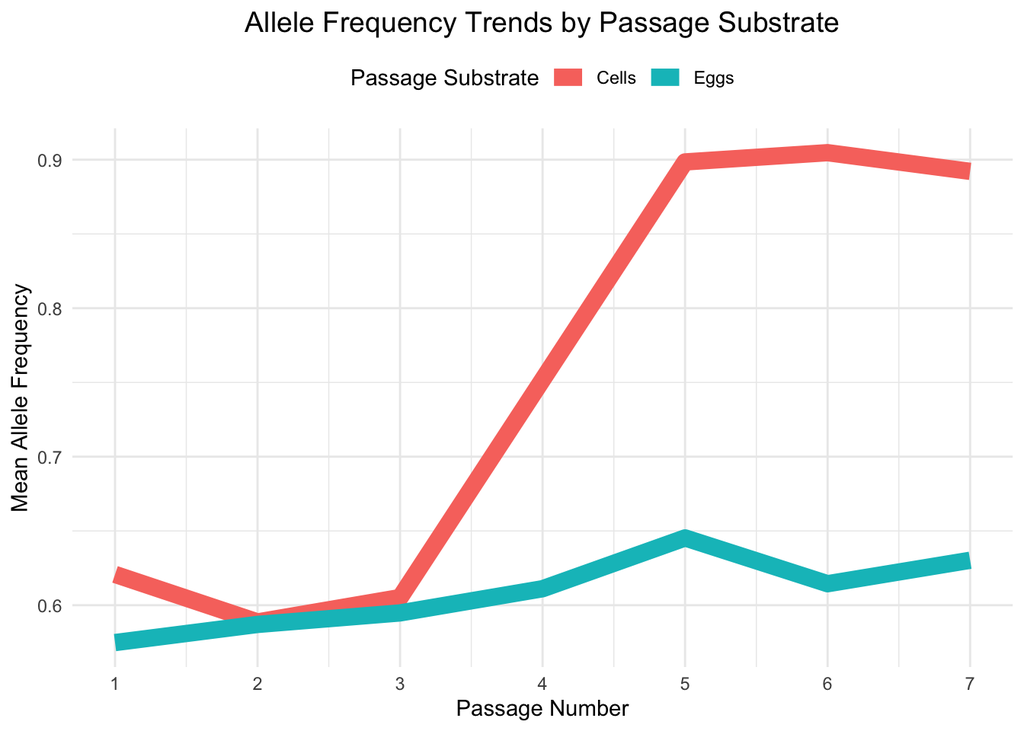

```r
ggplot(trend_plot_data, aes(x = Passage_Number, y = mean_AF, color = Passage_Substrate, group = Passage_Substrate)) +
  geom_line(linewidth = 4) +
  labs(
    title = "Allele Frequency Trends by Passage Substrate",
    x = "Passage Number",
    y = "Mean Allele Frequency",
    color = "Passage Substrate"
  ) +
  scale_x_continuous(breaks = 1:7) +
  theme_minimal() +
  theme(
    plot.title = element_text(hjust = 0.5, size = 14),
    legend.position = "top"
  )
```

### Trend test by isolate

Trend Test Grouped by Isolate, Position, and Substrate:

```r
results_trend_test_by_Isolate <- Data_Frame_Allele_Frequency %>%
  group_by(Position_Genome, Passage_Substrate, Isolate_ID) %>%
  summarise(
    test_result = list(
      prop.trend.test(success * 100, rep(100, length(success)), score = Passage_Number)
    ),
    .groups = "drop"
  )
```

Extract key results from trend test:

```r
results_summary_by_Isolate <- results_trend_test_by_Isolate %>%
  mutate(
    p_value = map_dbl(test_result, ~ .x$p.value),
    statistic = map_dbl(test_result, ~ .x$statistic)
  )
```

Filter significant results:

```r
results_trend_test_significant_by_Isolate <- results_summary_by_Isolate %>%
  filter(p_value <= 0.05)
```

Summarize data for trend plot:

```r
trend_plot_data_by_Isolate <- Data_Frame_Allele_Frequency %>%
  group_by(Isolate_ID, Passage_Substrate, Passage_Number) %>%
  summarise(
    mean_AF = mean(`%AF`, na.rm = TRUE),
    sd_AF = sd(`%AF`, na.rm = TRUE),
    .groups = "drop"
  )
```

Create the trend plot:

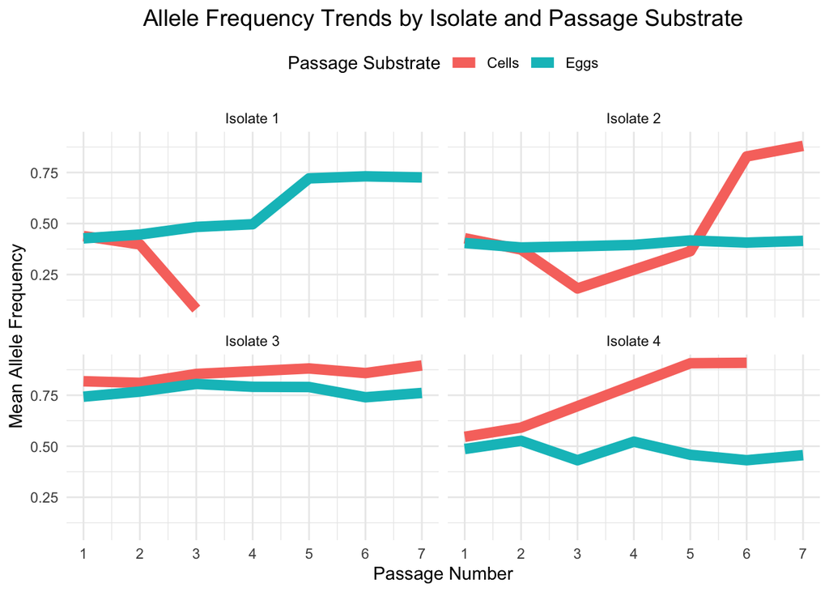

```r
ggplot(trend_plot_data_by_Isolate, aes(x = Passage_Number, y = mean_AF, color = Passage_Substrate, group = Passage_Substrate)) +
  geom_line(size = 3) +
  facet_wrap(~Isolate_ID) +
  labs(
    title = "Allele Frequency Trends by Isolate and Passage Substrate",
    x = "Passage Number",
    y = "Mean Allele Frequency",
    color = "Passage Substrate"
  ) +
  scale_x_continuous(breaks = 1:7) +
  theme_minimal() +
  theme(
    plot.title = element_text(hjust = 0.5, size = 14),
    legend.position = "top"
  )
```